# Taller Bioestadística

Caso 2. Cardiovascular

Yeyson Fabian Riaño | Natalia Piraquive | André Vargas

## Clasificación de variables

| Variable | Naturaleza | Continuidad | Escala | Rol |
| --- | --- | --- | --- | --- |
| Edad | Cuantitativa | Continua | Razón | Independiente |
| Sexo | Cualitativa | NA | Nominal | Independiente |
| Fuma | Cualitativa | NA | Nominal | Independiente |
| Cigarrillos/día | Cuantitativa | Discreta | Razón | Independiente |
| Diabetes | Cualitativa | NA | Nominal | Independiente |
| Prev. Hipertensión | Cualitativa | NA | Nominal | Independiente |
| Colesterol total | Cuantitativa | Continua | Razón | Independiente |
| PAS | Cuantitativa | Continua | Razón | Independiente |
| PAD | Cuantitativa | Continua | Razón | Independiente |
| IMC | Cuantitativa | Continua | Razón | Independiente |
| Frec. cardiaca | Cuantitativa | Discreta | Razón | Independiente |
| Glucosa | Cuantitativa | Continua | Razón | Independiente |
| Riesgo ECV 10 años | Cualitativa | NA | Nominal | Dependiente |

## Análisis variables cuantitativas

- **Edad:** Distribución simétrica. Promedio 49.5 ± 9 años. El 50% entre 42 y 56 años.
- **Cigarrillos/día:** Asimetría positiva. Mediana = 0. Valores atípicos superiores.
- **Colesterol total:** Asimetría positiva. Mediana sobre punto de corte. Valores atípicos superiores.
- **Presión sistólica:** Asimetría positiva. Mediana en rango normal. Valores atípicos superiores.
- **Presión diastólica:** Distribución simétrica. Gran cantidad de valores atípicos superiores.
- **IMC:** Distribución simétrica. Promedio 25.8 ± 4 kg/m². Valores atípicos superiores.
- **Frecuencia cardiaca:** Distribución simétrica. Promedio 76 ± 12 lpm.
- **Glucosa:** Asimetría positiva. Mediana en rango normal. Valores atípicos superiores e inferiores.

> Se evidencia heterogeneidad en el perfil cardiometabólico con un subgrupo de alto riesgo

## Distribución variables cuantitativas

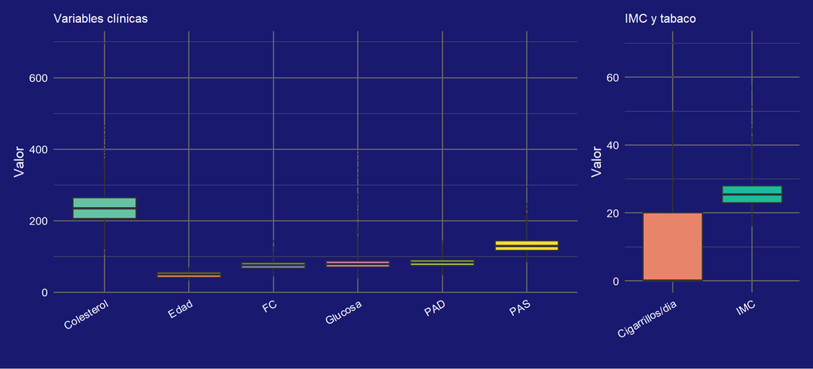

## Análisis variables cualitativas

- Predominó el **sexo femenino (56.7%)**
- Hipertensión arterial en el **31.5%**
- Tabaquismo en el **49.8%**
- Diabetes en el **2.6%**
- Riesgo CV a 10 años: **15.1%**

> Alta prevalencia de tabaquismo e hipertensión respalda la existencia de un grupo con acumulación de factores de riesgo

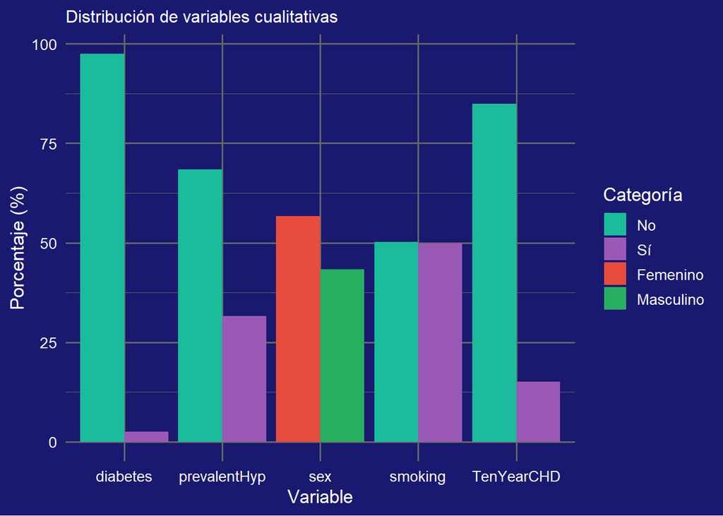

## Factores de riesgo según sexo de variables cuantitativas

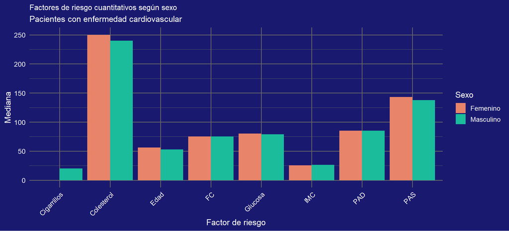

## Factores de riesgo según sexo de variables cualitativas

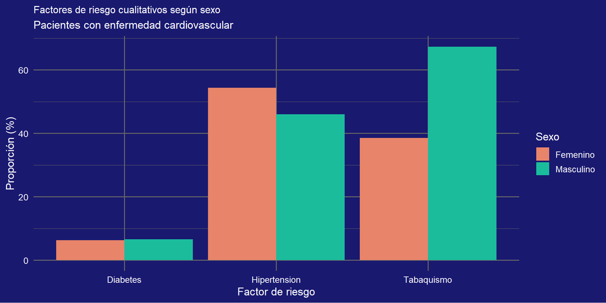

> Las mujeres presentan mayor edad, PAS, colesterol e hipertensión. Los hombres mayor consumo de cigarrillos e IMC

## ECV según edad y PA

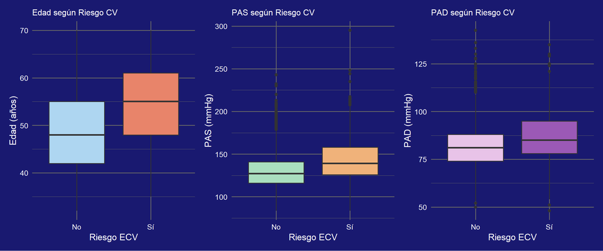